# Explore_bikeshare_data

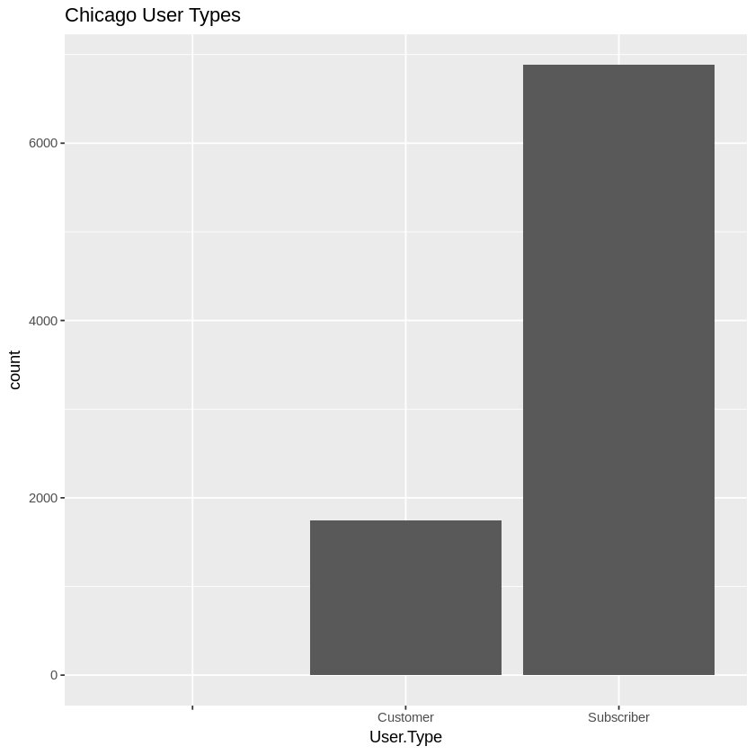

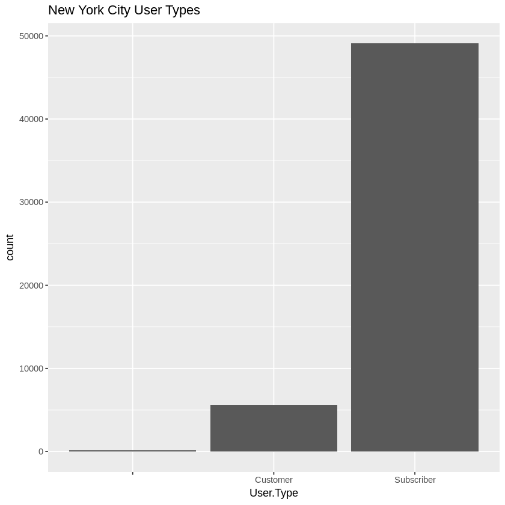

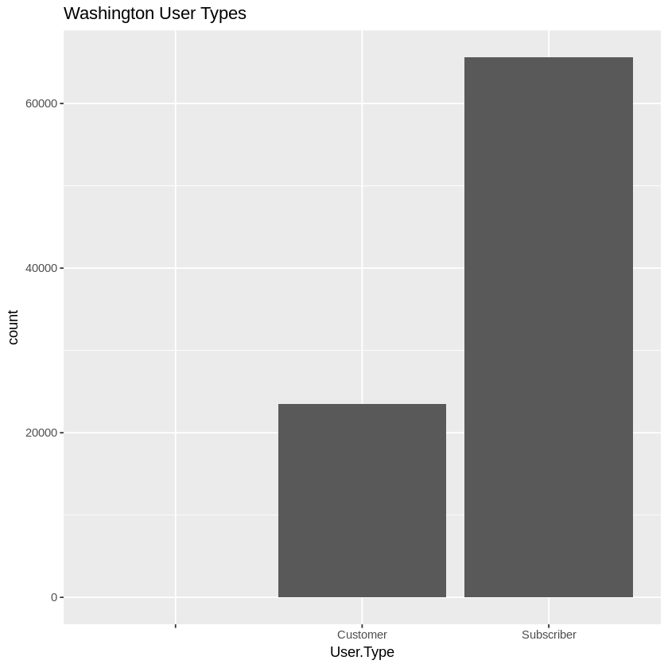

```r
user_types_chic <- chic %>%
  group_by(User.Type) %>%
  summarise(count = n())

user_types_nyc <- nyc %>%
  group_by(User.Type) %>%
  summarise(count = n())


user_types_wash <- wash %>%
  group_by(User.Type) %>%
  summarise(count = n())

ggplot(user_types_chic)+
  geom_col(aes(User.Type, count))+
  labs(title = 'Chicago User Types')

ggplot(user_types_nyc)+
  geom_col(aes(User.Type, count))+
  labs(title = 'New York City User Types')

ggplot(user_types_wash)+
  geom_col(aes(User.Type, count))+
  labs(title = 'Washington User Types')
```

**There are substatially way more subscribers in all 3 cities as compared to customers**

# Question 3b

**What are the counts of each gender?**

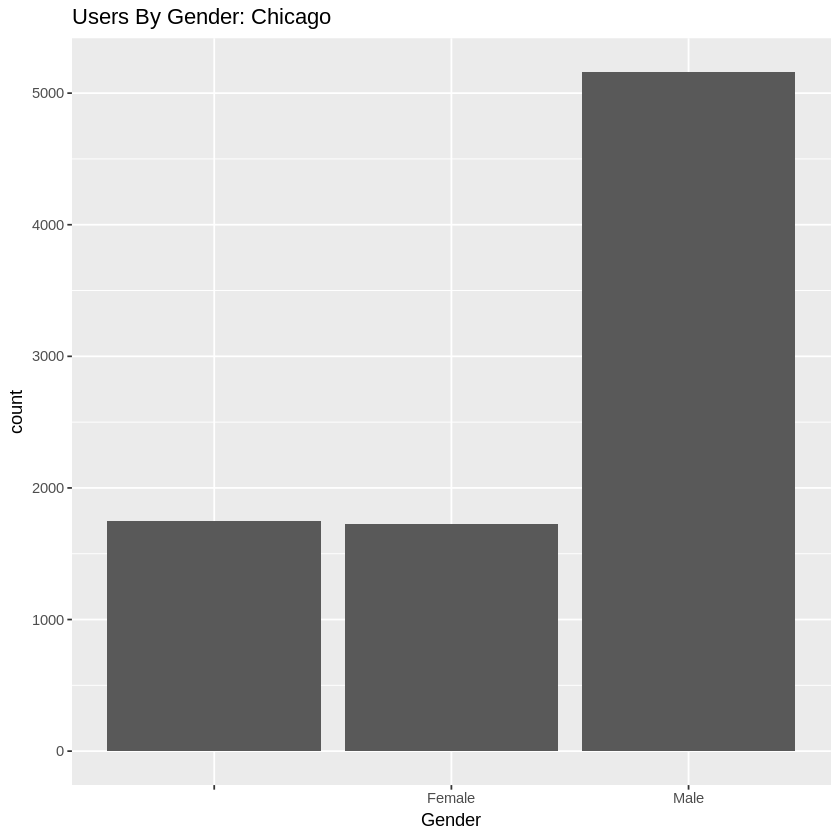

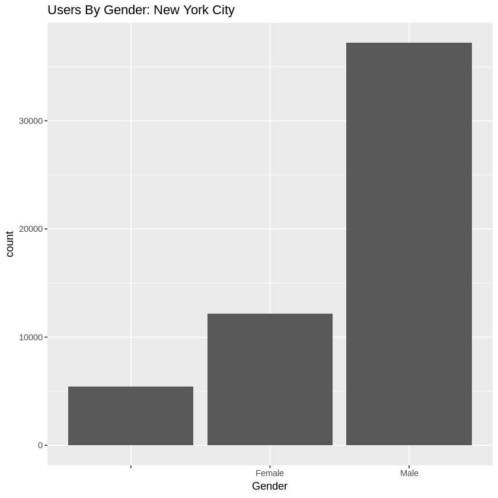

```r
gender_types_chic <- chic %>%
  group_by(Gender) %>%
  summarise(count = n())

gender_types_nyc <- nyc %>%
  group_by(Gender) %>%
  summarise(count = n())

ggplot(gender_types_chic)+
  geom_col(aes(Gender, count))+
  labs(title = 'Users By Gender: Chicago')


ggplot(gender_types_nyc)+
  geom_col(aes(Gender, count))+
  labs(title = 'Users By Gender: New York City')
```

Both cities show that disproportionately more males use the rides as compared to females. There is a significant number of missing values in both cities. This could be due to persons who neither identify as male or female

## Question 3c

**What are the earliest, most recent, most common year of birth (only available for NYC and Chicago)?**

```r
frequent_year_chicago <- chic%>%
  group_by(Birth.Year)%>%
  summarise(count = n())%>%
  arrange(desc(count))%>%
  filter(count>300)     #to display the topmost frequent years of birthh only

head(frequent_year_chicago)

summary(chic$Birth.Year)            #this gives the min and max years, no mode (most frequent year)
```

| Birth.Year | count |
| --- | --- |
| NA | 1747 |
| 1989 | 388 |
| 1990 | 384 |
| 1988 | 362 |
| 1987 | 360 |
| 1991 | 357 |

```
   Min. 1st Qu.  Median    Mean 3rd Qu.    Max.    NA's
   1899    1975    1984    1981    1989    2002    1747
```

The earliest year in Chicago is 1899. The latest is 2002. The most frequent is 1989

```r
frequent_year_nyc <- nyc%>%
  group_by(Birth.Year)%>%
  summarise(count = n())%>%
  arrange(desc(count))%>%
  filter(count>300)     #to display the topmost frequent years of birthh only

head(frequent_year_nyc)

summary(nyc$Birth.Year)            #this gives the min and max years, no mode (most frequent year)
```

| Birth.Year | count |
| --- | --- |
| NA | 5218 |
| 1989 | 2050 |
| 1985 | 2039 |
| 1990 | 2027 |
| 1986 | 1987 |
| 1987 | 1976 |

```
   Min. 1st Qu.  Median    Mean 3rd Qu.    Max.    NA's
   1885    1970    1981    1978    1988    2001    5218
```

The earliest year in NYC is 1885. The latest is 2001. The most frequent is 1989, same as in Chicago

## Finishing Up

> Congratulations! You have reached the end of the Explore Bikeshare Data Project. You should be very proud of all you have accomplished!

> **Tip**: Once you are satisfied with your work here, check over your report to make sure that it is satisfies all the areas of the [rubric](https://review.udacity.com/#!/rubrics/2508/view).

## Directions to Submit

> Before you submit your project, you need to create a .html or .pdf version of this notebook in the workspace here. To do that, run the code cell below. If it worked correctly, you should get a return code of 0, and you should see the generated .html file in the workspace directory (click on the orange Jupyter icon in the upper left).

> Alternatively, you can download this report as .html via the **File** > **Download as** submenu, and then manually upload it into the workspace directory by clicking on the orange Jupyter icon in the upper left, then using the Upload button.

> Once you've done this, you can submit your project by clicking on the "Submit Project" button in the lower right here. This will create and submit a zip file with this .ipynb doc and the .html or .pdf version you created. Congratulations!

```r
system('python -m nbconvert Explore_bikeshare_data.ipynb')
```